# World Sustainability Dataset EDA + Plotting

# World Sustainability Dataset EDA

This dataset was aggregated from several sources initially for the TrueCue Women+Data Hackathon, and then made available to the larger public. Dataset can be found [here](https://www.kaggle.com/datasets/truecue/worldsustainabilitydataset). This dataset tracks the performance of 173 counties in terms of several measures of global sustainability over 19 years.

## Processing

Read in data and do initial exploration

```r
data.raw <- read.csv('data/WorldSustainabilityDataset.csv', header = TRUE)
head(data.raw)
```

|  | Country.Name | Country.Code | Year | Access.to.electricity....of.population....EG.ELC.ACCS.ZS | Adjusted.net.national.income.per.capita..annual...growth....NY.ADJ.NNTY.PC.KD.ZG | Adjusted.net.savings..excluding.particulate.emission.damage....of.GNI....NY.ADJ.SVNX.GN.ZS | Adjusted.savings..carbon.dioxide.damage....of.GNI....NY.ADJ.DCO2.GN.ZS | Adjusted.savings..natural.resources.depletion....of.GNI....NY.ADJ.DRES.GN.ZS | Adjusted.savings..net.forest.depletion....of.GNI....NY.ADJ.DFOR.GN.ZS | Adjusted.savings..particulate.emission.damage....of.GNI....NY.ADJ.DPEM.GN.ZS | Automated.teller.machines..ATMs...per.100.000.adults....FB.ATM.TOTL.P5 | Broad.money....of.GDP....FM.LBL.BMNY.GD.ZS | Children.out.of.school....of.primary.school.age....SE.PRM.UNER.ZS | Compulsory.education..duration..years....SE.COM.DURS | Cost.of.business.start.up.procedures..female....of.GNI.per.capita....IC.REG.COST.PC.FE.ZS | Cost.of.business.start.up.procedures..male....of.GNI.per.capita....IC.REG.COST.PC.MA.ZS | Exports.of.goods.and.services....of.GDP....NE.EXP.GNFS.ZS | Final.consumption.expenditure....of.GDP....NE.CON.TOTL.ZS | GDP..current.US.....NY.GDP.MKTP.CD | GDP.per.capita..current.US.....NY.GDP.PCAP.CD | General.government.final.consumption.expenditure....of.GDP....NE.CON.GOVT.ZS | Gross.national.expenditure....of.GDP....NE.DAB.TOTL.ZS | Gross.savings....of.GDP....NY.GNS.ICTR.ZS | Imports.of.goods.and.services....of.GDP....NE.IMP.GNFS.ZS | Inflation..consumer.prices..annual......FP.CPI.TOTL.ZG | Primary.completion.rate..total....of.relevant.age.group....SE.PRM.CMPT.ZS | Proportion.of.seats.held.by.women.in.national.parliaments.......SG.GEN.PARL.ZS | Pupil.teacher.ratio..primary...SE.PRM.ENRL.TC.ZS | Renewable.electricity.output....of.total.electricity.output....EG.ELC.RNEW.ZS | … |
| --- | --- | --- | --- | --- | --- | --- | --- | --- | --- | --- | --- | --- | --- | --- | --- | --- | --- | --- | --- | --- | --- | --- | --- | --- | --- | --- | --- | --- | --- | --- |
| 1 | Aruba | ABW | 2000 | 91.6604 | NA | 15.392211 | 2.389134 | 0.000190031 | 0.000190031 | NA | NA | 51.83454 | 1.60268 | NA | NA | NA | 74.40032 | 70.79213 | 1873452514 | 20617.75 | 21.41059 | 96.28804 | 23.730274 | 70.67285 | 4.044021 | 97.14286 | NA | 19.05967 | 0 | … |
| 2 | Aruba | ABW | 2001 | 100.0000 | NA | 11.491930 | 2.509046 | 0.000213978 | 0.000213978 | NA | NA | 53.55252 | 0.32258 | NA | NA | NA | 70.49753 | 74.33809 | 1920111732 | 20670.37 | 24.52720 | 98.05063 | 19.327902 | 68.54815 | 2.883604 | 94.40407 | NA | 18.94779 | 0 | … |
| 3 | Aruba | ABW | 2002 | 100.0000 | NA | 3.893620 | 2.721385 | 0.000222866 | 0.000222866 | NA | NA | 58.52086 | 1.81634 | NA | NA | NA | 64.92086 | 77.55396 | 1941340782 | 20436.89 | 25.15108 | 104.46043 | 12.016691 | 69.38129 | 3.315247 | 94.75524 | NA | 19.06977 | 0 | … |
| 4 | Aruba | ABW | 2003 | 100.0000 | NA | 6.713863 | 2.733676 | 0.000243312 | 0.000243312 | NA | NA | 61.19679 | 3.32156 | NA | NA | NA | 63.10116 | 78.55169 | 2021229050 | 20833.98 | 24.70978 | 107.76672 | 14.461857 | 70.86788 | 3.656365 | 90.21592 | NA | 18.43017 | 0 | … |
| 5 | Aruba | ABW | 2004 | 100.0000 | NA | 9.801576 | 2.678363 | 0.000256001 | 0.000256001 | NA | NA | 57.29005 | 2.17652 | NA | NA | NA | 65.07897 | 74.70544 | 2228491620 | 22568.37 | 23.16370 | 103.48458 | 17.096515 | 68.56355 | 2.529129 | 90.55990 | NA | 18.45109 | 0 | … |
| 6 | Aruba | ABW | 2005 | 100.0000 | NA | -12.523180 | 3.413409 | 0.000314319 | 0.000314319 | NA | NA | 58.16874 | 1.64077 | NA | NA | NA | 68.55225 | 75.81496 | 2330726257 | 23300.74 | 23.13039 | 109.39597 | -2.041702 | 77.94823 | 3.397787 | 88.19797 | NA | 18.07760 | 0 | … |

Looks like there are some missing elements labeled as empty instead of NA. Let’s fix this before proceeding.

```r
data.raw[data.raw == ""] <- NA
```

There are quite a few missing fields. Let’s get fields have at least a 90% complete rate.

```r
data.90 <- data.raw[, apply(data.raw, 2, function(col)sum(is.na(col))/length(col)) < 0.10]
skim(data.90)
```

```
── Data Summary ────────────────────────
                           Values
Name                       data.90
Number of rows             3287
Number of columns          32
_______________________
Column type frequency:
  character                6
  numeric                  26
________________________
Group variables            None

── Variable type: character ───────────────────────────────────────────────────────────────────────────────────────────────────────────────────────────────────────────────────────
  skim_variable                                 n_missing complete_rate   min   max empty n_unique whitespace
1 Country.Name                                          0         1         4    30     0      173          0
2 Country.Code                                          0         1         3     3     0      173          0
3 Continent                                             2         0.999     4    13     0        6          0
4 Income.Classification..World.Bank.Definition.         2         0.999    10    19     0        4          0
5 Regime.Type..RoW.Measure.Definition.                211         0.936    16    19     0        4          0
6 World.Regions..UN.SDG.Definition.                     2         0.999     7    32     0        7          0

── Variable type: numeric ─────────────────────────────────────────────────────────────────────────────────────────────────────────────────────────────────────────────────────────
   skim_variable                                                                         n_missing complete_rate     mean      sd       p0     p25      p50      p75    p100 hist
 1 Year                                                                                          0         1     2.01e+ 3 5.48e 0  2   e+3 2.00e+3 2.01e+ 3 2.01e+ 3 2.02e 3 ▇▇▆▇▇
 2 Access.to.electricity....of.population....EG.ELC.ACCS.ZS                                     94         0.971 7.93e+ 1 3.04e 1  1.27e+0 6.29e+1 9.87e+ 1 1   e+ 2 1   e 2 ▁▁▁▁▇
 3 Adjusted.savings..carbon.dioxide.damage....of.GNI....NY.ADJ.DCO2.GN.ZS                       67         0.980 1.74e+ 0 1.96e 0  9.03e-2 7.41e-1 1.15e+ 0 2.06e+ 0 2.71e 1 ▇▁▁▁▁
 4 Adjusted.savings..natural.resources.depletion....of.GNI....NY.ADJ.DRES.GN.ZS                193         0.941 3.81e+ 0 6.96e 0  0       7.85e-2 8.79e- 1 4.66e+ 0 7.13e 1 ▇▁▁▁▁
 5 Adjusted.savings..net.forest.depletion....of.GNI....NY.ADJ.DFOR.GN.ZS                       176         0.946 6.93e- 1 2.66e 0  0       0       0        9.70e- 2 4.08e 1 ▇▁▁▁▁
 6 Adjusted.savings..particulate.emission.damage....of.GNI....NY.ADJ.DPEM.GN.ZS                188         0.943 8.81e- 1 1.08e 0  9.50e-3 1.50e-1 3.89e- 1 1.29e+ 0 6.54e 0 ▇▂▁▁▁
 7 Compulsory.education..duration..years....SE.COM.DURS                                        308         0.906 9.33e+ 0 2.21e 0  4   e+0 8   e+0 9   e+ 0 1   e+ 1 1.7 e 1 ▃▇▆▃▁
 8 Exports.of.goods.and.services....of.GDP....NE.EXP.GNFS.ZS                                   169         0.949 4.22e+ 1 2.98e 1  9.95e-2 2.39e+1 3.56e+ 1 5.24e+ 1 2.29e 2 ▇▃▁▁▁
 9 Final.consumption.expenditure....of.GDP....NE.CON.TOTL.ZS                                   240         0.927 8.04e+ 1 1.93e 1  1.67e+1 7.13e+1 7.95e+ 1 8.97e+ 1 2.42e 2 ▁▇▁▁▁
```

[output cut: 17 more lines]

What do we get if we remove the NAs. Hoe many countries do we still have data on?

```r
data.processed <- na.omit(data.90)
# How many countries?
n.countries <- length(unique(data.processed$Country.Name))
n.countries
```

```
[1] 141
```

Ok good, now let’s rename some of our variables to be easier to read and work with

```r
names(data.processed)[4] <- "Electricity.Access"
names(data.processed)[5] <- "Adj.SavingNetCO2Damage"
names(data.processed)[6] <- "Adj.SavingNaturalResourceDepletion"
names(data.processed)[7] <- "Adj.SavingNetForestDepletion"
names(data.processed)[8] <- "Adj.SavingParticulateEmissions"
names(data.processed)[9] <- "CompulsoryEducationDurationYears"
names(data.processed)[10] <- "ExportGoodsServices.GDP"
names(data.processed)[11] <- "FinalConsumptionExpenditure.GDP"
names(data.processed)[12] <- "GDP.Current"
names(data.processed)[13] <- "GDP.PerCapita.Current"
names(data.processed)[14] <- "Govt.FinalConsumptionExpenditure.GDP"
names(data.processed)[15] <- "GrossNationalExpenditure.GDP"
names(data.processed)[16] <- "ImportGoodsServices.GDP"
names(data.processed)[17] <- "ConsumerPriceInflation"
names(data.processed)[18] <- "ProportionParliamentSeats.Women"
names(data.processed)[19] <- "RenewableEnergyConsumption.pctOfTotal"
names(data.processed)[20] <- "Trade.GDP"
names(data.processed)[21] <- "WomenInBusinessLawIndex"
names(data.processed)[22] <- "AnnualProductionBasedCO2Emissions"
names(data.processed)[24] <- "WorldBankIncomeClass"
names(data.processed)[25] <- "IndividualsUsingInternet"
names(data.processed)[26] <- "LifeExpenctancy"
names(data.processed)[27] <- "TotalPopulation"
names(data.processed)[28] <- "RegimeType"
names(data.processed)[29] <- "RuralPopulation.Prop"
names(data.processed)[30] <- "TotalNaturalResources.GDP"
names(data.processed)[31] <- "UrbanPopulation.Prop"
names(data.processed)[32] <- "WorldRegion"
names(data.processed)
```

```
 [1] "Country.Name"                          "Country.Code"                          "Year"                                  "Electricity.Access"
 [5] "Adj.SavingNetCO2Damage"                "Adj.SavingNaturalResourceDepletion"    "Adj.SavingNetForestDepletion"          "Adj.SavingParticulateEmissions"
 [9] "CompulsoryEducationDurationYears"      "ExportGoodsServices.GDP"               "FinalConsumptionExpenditure.GDP"       "GDP.Current"
[13] "GDP.PerCapita.Current"                 "Govt.FinalConsumptionExpenditure.GDP"  "GrossNationalExpenditure.GDP"          "ImportGoodsServices.GDP"
[17] "ConsumerPriceInflation"                "ProportionParliamentSeats.Women"       "RenewableEnergyConsumption.pctOfTotal" "Trade.GDP"
[21] "WomenInBusinessLawIndex"               "AnnualProductionBasedCO2Emissions"     "Continent"                             "WorldBankIncomeClass"
[25] "IndividualsUsingInternet"              "LifeExpenctancy"                       "TotalPopulation"                       "RegimeType"
[29] "RuralPopulation.Prop"                  "TotalNaturalResources.GDP"             "UrbanPopulation.Prop"                  "WorldRegion"
```

Set Certain Things to Factor

```r
data.processed$RegimeType <- as.factor(data.processed$RegimeType)
data.processed$WorldRegion <- as.factor(data.processed$WorldRegion)
data.processed$WorldBankIncomeClass <- as.factor(data.processed$WorldBankIncomeClass)
```

Export the processed data

```r
write.csv(data.processed, "data/WorldSustainabilityData_Processed.csv", row.names = FALSE)
```

## EDA

Now that we have processed our data, let’s do some EDA

First let’s do some exploratory plotting.

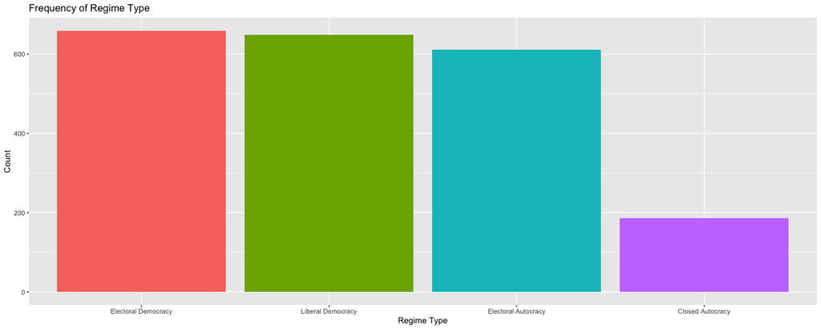

```r
# Frequency of Regime Types in our data
ggplot(data.processed, aes(x=fct_infreq(RegimeType), fill=fct_infreq(RegimeType))) +
  geom_bar(show.legend = FALSE) +
  xlab("Regime Type") +
  ylab("Count") +
  ggtitle("Frequency of Regime Type")
```

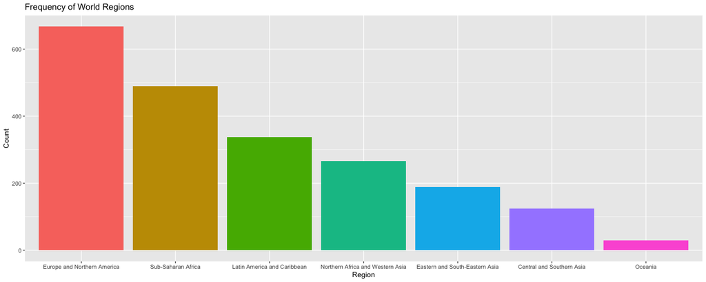

```r
# World Region Representation
ggplot(data.processed, aes(x=fct_infreq(WorldRegion), fill=fct_infreq(WorldRegion))) +
  geom_bar(show.legend = FALSE) +
  xlab("Region") +
  ylab("Count") +
  ggtitle("Frequency of World Regions")
```

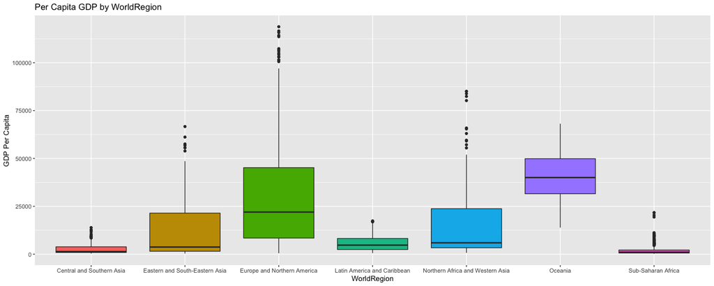

```r
# GDP per Capita by WorldRegion
ggplot(data.processed, aes(y=GDP.PerCapita.Current, x=WorldRegion, fill=WorldRegion)) +
  geom_boxplot(show.legend = FALSE) +
  xlab("WorldRegion") +
  ylab("GDP Per Capita") +
  ggtitle("Per Capita GDP by WorldRegion")
```

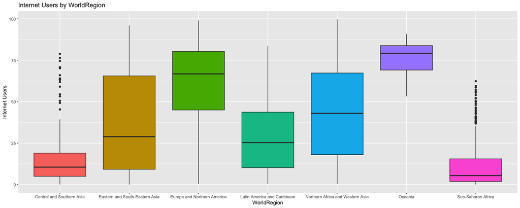

```r
# Internet Use by WorldRegion
ggplot(data.processed, aes(y=IndividualsUsingInternet, x=WorldRegion, fill=WorldRegion)) +
  geom_boxplot(show.legend = FALSE) +
  xlab("WorldRegion") +
  ylab("Internet Users") +
  ggtitle("Internet Users by WorldRegion")
```

Ho wmuch do things change by year

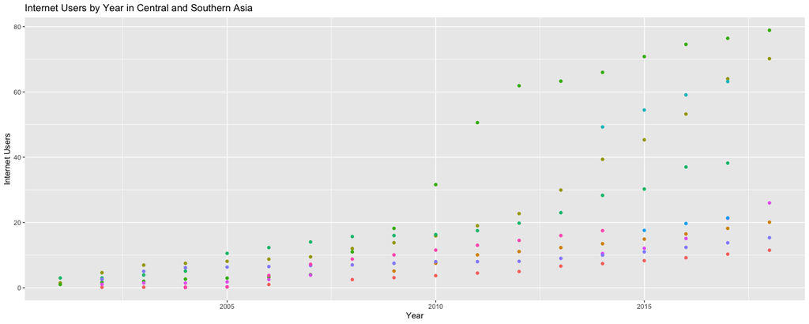

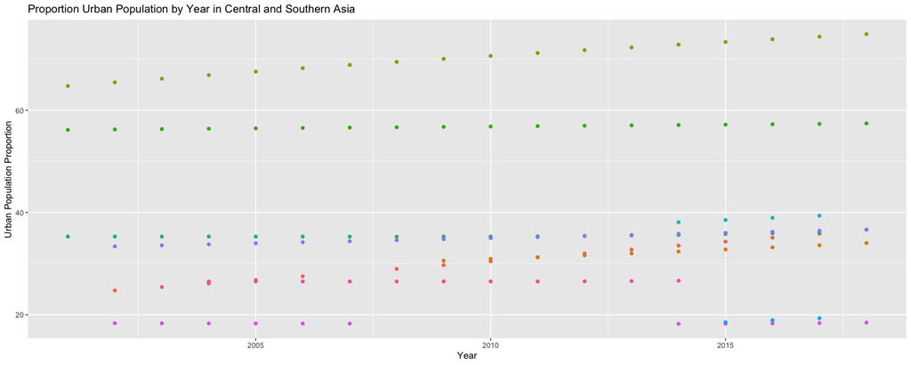